# Part I - (Ford GoBike System Data Exploration)

## Introduction

> This dataset contains information about individual bike rides in the Ford GoBike bike-sharing system, covering the greater San Francisco Bay Area during February 2019. The dataset includes details like trip duration, start and end times, station names, user type (Subscriber or Customer), and more. The goal of this analysis is to explore ride patterns and differences between user types, and to uncover trends related to time, duration, and stations.

## Preliminary Wrangling

```python
# import all packages and set plots to be embedded inline
import numpy as np
import pandas as pd
import matplotlib.pyplot as plt
import seaborn as sb

%matplotlib inline
```

> Load in your dataset and describe its properties through the questions below. Try and motivate your exploration goals through this section.

```python
# Import necessary libraries for data manipulation and visualization
import numpy as np
import pandas as pd
import matplotlib.pyplot as plt
import seaborn as sb

%matplotlib inline

# Load dataset
df = pd.read_csv('201902-fordgobike-tripdata.csv')

# Display first 5 rows to preview data
print(df.head())

# Show dataset structure: columns, types, non-null counts
print(df.info())

# Show basic statistical description of numerical columns
print(df.describe())
```

```
   duration_sec                start_time                  end_time  \
0         52185  2019-02-28 17:32:10.1450  2019-03-01 08:01:55.9750
1         42521  2019-02-28 18:53:21.7890  2019-03-01 06:42:03.0560
2         61854  2019-02-28 12:13:13.2180  2019-03-01 05:24:08.1460
3         36490  2019-02-28 17:54:26.0100  2019-03-01 04:02:36.8420
4          1585  2019-02-28 23:54:18.5490  2019-03-01 00:20:44.0740

   start_station_id                                start_station_name  \
0              21.0  Montgomery St BART Station (Market St at 2nd St)
1              23.0                     The Embarcadero at Steuart St
2              86.0                           Market St at Dolores St
3             375.0                           Grove St at Masonic Ave
4               7.0                               Frank H Ogawa Plaza

   start_station_latitude  start_station_longitude  end_station_id  \
0               37.789625              -122.400811            13.0
1               37.791464              -122.391034            81.0
2               37.769305              -122.426826             3.0
3               37.774836              -122.446546            70.0
4               37.804562              -122.271738           222.0

                               end_station_name  end_station_latitude  \
0                Commercial St at Montgomery St             37.794231
1                            Berry St at 4th St             37.775880
2  Powell St BART Station (Market St at 4th St)             37.786375
3                        Central Ave at Fell St             37.773311
4                         10th Ave at E 15th St             37.792714

   end_station_longitude  bike_id   user_type  member_birth_year  \
0            -122.402923     4902    Customer             1984.0
1            -122.393170     2535    Customer                NaN
2            -122.404904     5905    Customer             1972.0
3            -122.444293     6638  Subscriber             1989.0
4            -122.248780     4898  Subscriber             1974.0

  member_gender bike_share_for_all_trip
0          Male                      No
1           NaN                      No
2          Male                      No
3         Other                      No
```

[output cut: 39 more lines]

```
min                -122.453704        3.000000             37.317298
25%                -122.412408       44.000000             37.770407
50%                -122.398285      100.000000             37.781010
75%                -122.286533      235.000000             37.797320
max                -121.874119      398.000000             37.880222

       end_station_longitude        bike_id  member_birth_year
count          183412.000000  183412.000000      175147.000000
mean             -122.352250    4472.906375        1984.806437
std                 0.116673    1664.383394          10.116689
min              -122.453704      11.000000        1878.000000
25%              -122.411726    3777.000000        1980.000000
50%              -122.398279    4958.000000        1987.000000
75%              -122.288045    5502.000000        1992.000000
max              -121.874119    6645.000000        2001.000000
```

### What is the structure of your dataset?

> The dataset consists of approximately 183,412 rows and multiple columns, including information about trip duration, start and end times, station names and locations, bike ID, user type (Subscriber/Customer), member birth year, and gender. Some columns contain missing data (e.g., member_birth_year has fewer non-null values). Most columns are either numeric (e.g., duration_sec, member_birth_year) or categorical (e.g., user_type, bike_id).

### What is/are the main feature(s) of interest in your dataset?

> The main features of interest are `duration_sec` (trip duration), `user_type` (Subscriber or Customer), and temporal features (such as start time and end time) to explore usage patterns.

### What features in the dataset do you think will help support your investigation into your feature(s) of interest?

> Features like `start_time`, `end_time`, `start_station_name`, `end_station_name`, `member_birth_year`, and `member_gender` will help in understanding how trip duration and user type vary by time, location, age, and gender.

## Univariate Exploration

> **Question:** What is the distribution of trip duration in seconds?

> **Visualization:** The histogram below shows the distribution of trip duration in seconds.

> **Observation:** The distribution of trip duration is right-skewed, with most trips lasting less than 1000 seconds. There are a few trips with very long durations, but these are rare.

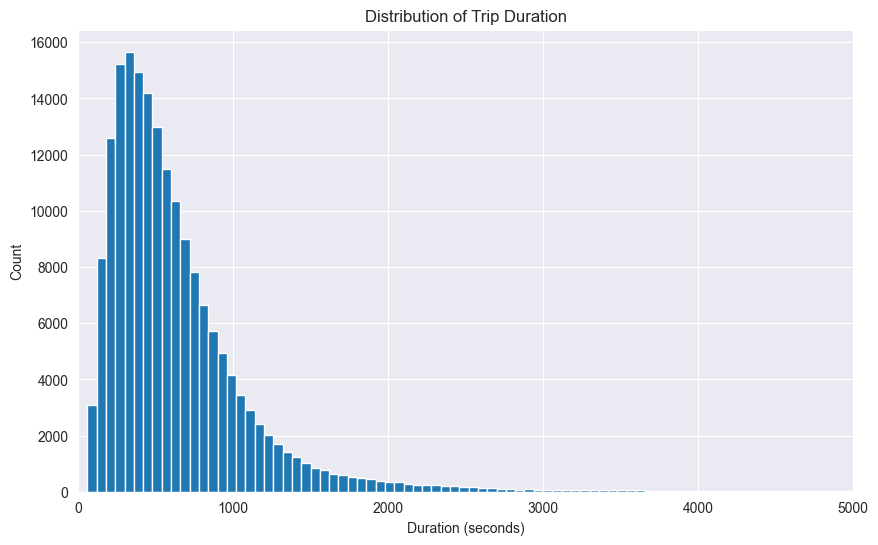

```python
def set_plot_labels(title, x_label, y_label):
    plt.title(title)
    plt.xlabel(x_label)
    plt.ylabel(y_label)

plt.figure(figsize=(10,6))
bins = np.arange(0, df['duration_sec'].max()+60, 60)
plt.hist(df['duration_sec'], bins=bins)
set_plot_labels('Distribution of Trip Duration', 'Duration (seconds)', 'Count')
plt.xlim(0, 5000)
plt.show()
```

### Question:

> What is the distribution of user types (Subscriber vs Customer)?

### Observation:

The majority of users are Subscribers, while Customers form a smaller portion of the users.

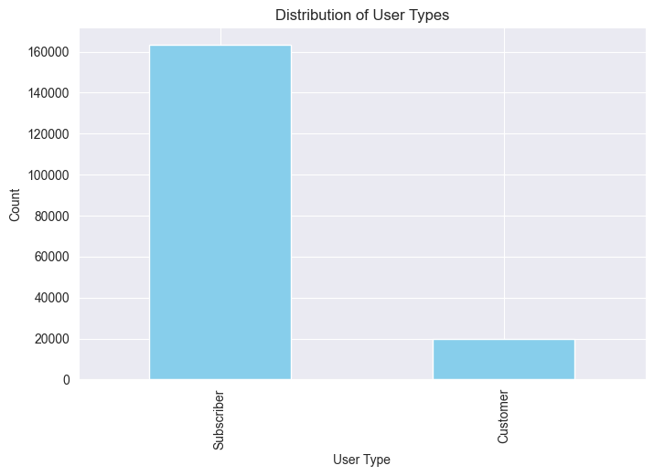

```python
# Get count of each user type
user_counts = df['user_type'].value_counts()

# Create bar plot of user types
plt.figure(figsize=(8,5))
user_counts.plot(kind='bar', color='skyblue')

# Set title and labels
set_plot_labels('Distribution of User Types', 'User Type', 'Count')

# Display the plot
plt.show()
```

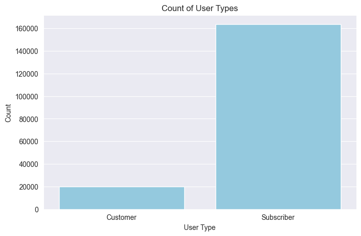

```python
# Create count plot of user types using seaborn
plt.figure(figsize=(8,5))
sb.countplot(x='user_type', data=df, color='skyblue')

# Set title and labels
set_plot_labels('Count of User Types', 'User Type', 'Count')

# Display the plot
plt.show()
```

### Discuss the distribution(s) of your variable(s) of interest. Were there any unusual points? Did you need to perform any transformations?

> The distribution of trip duration is right-skewed, with most trips lasting less than 1000 seconds. There are a few unusual points where the duration is very long, indicating rare cases of unusually extended trips. No transformations were applied at this stage, but extreme values were noted for potential further cleaning.

### Of the features you investigated, were there any unusual distributions? Did you perform any operations on the data to tidy, adjust, or change the form of the data? If so, why did you do this?

> Yes, the trip duration feature had a long tail with some unusually high values. While no operations were performed at this stage, these values might require further attention (e.g., filtering or transformation) during later stages of analysis to prevent distortion of summary statistics and visualizations.

## Bivariate Exploration

### Question:

How does trip duration vary by user type (Subscriber vs Customer)?

### Observation:

It appears that subscribers generally have shorter trip durations compared to customers. The distribution of trip duration differs noticeably between the two groups, with customers tending to have longer trips.

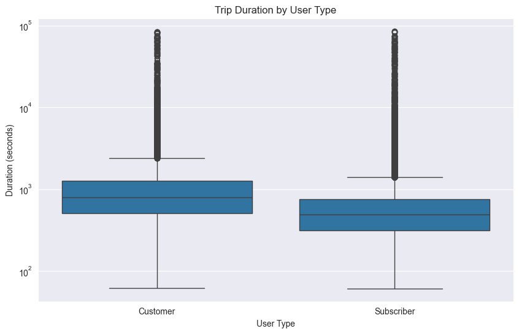

```python
plt.figure(figsize=(10,6))
sb.boxplot(x='user_type', y='duration_sec', data=df)
plt.yscale('log')
set_plot_labels('Trip Duration by User Type', 'User Type', 'Duration (seconds)')
plt.show()
```

**Question:** What is the relationship between trip duration and user type?

**Visualization:** The scatter plot below shows the relationship between trip duration and user type.

**Observation:** The plot shows that most subscribers have shorter trip durations, while some customers have longer trip durations.

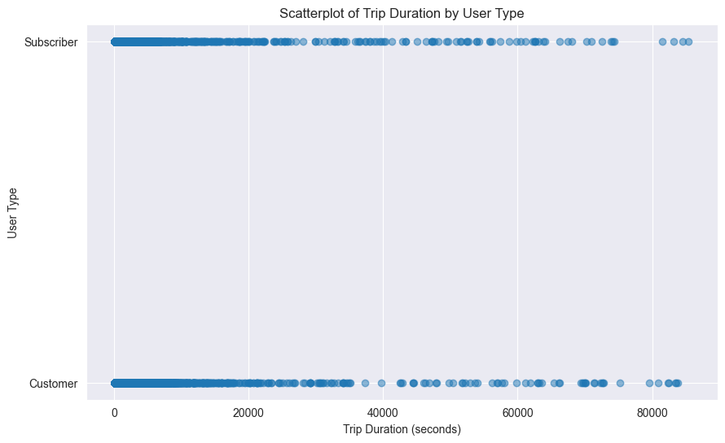

```python
plt.figure(figsize=(10,6))
plt.scatter(df['duration_sec'], df['user_type'], alpha=0.5)
set_plot_labels('Scatterplot of Trip Duration by User Type', 'Trip Duration (seconds)', 'User Type')
plt.show()
```

**Question:** How does trip duration vary with member birth year?

**Visualization:** The scatter plot below shows the relationship between trip duration and member birth year.

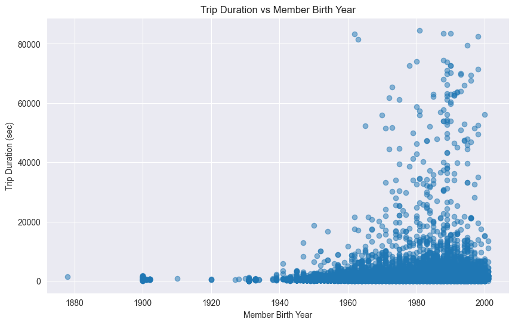

```python
plt.figure(figsize=(10,6))  # Create a figure with size 10x6
plt.scatter(df['member_birth_year'], df['duration_sec'], alpha=0.5)  # Plot scatter of birth year vs duration
set_plot_labels('Trip Duration vs Member Birth Year', 'Member Birth Year', 'Trip Duration (sec)')  # Set title and axis labels
plt.show()  # Display the plot
```

**Question:** What is the relationship between start and end stations?

**Visualization:** The heatmap below shows the frequency of trips between start and end stations.

**Observation:** We can observe that certain station pairs have much higher trip frequencies, indicating popular routes in the dataset.

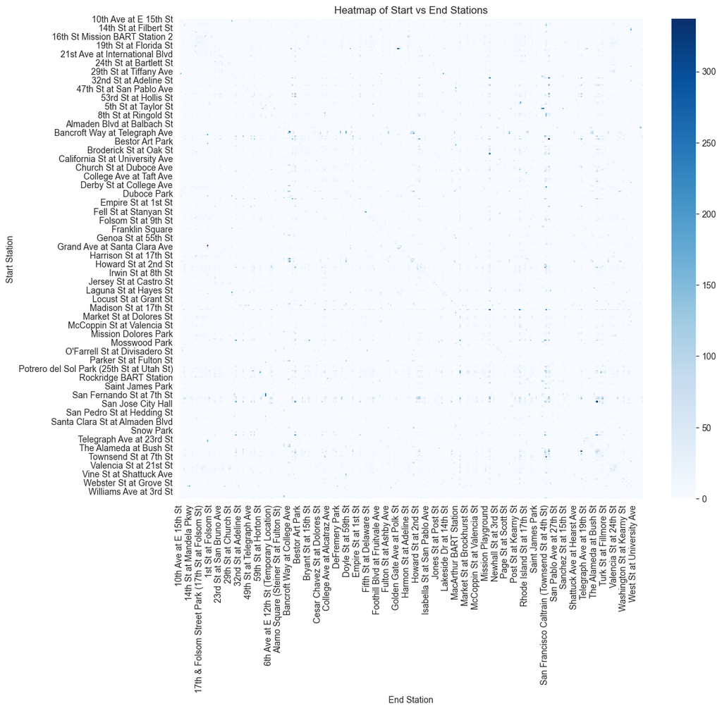

```python
ct = pd.crosstab(df['start_station_name'], df['end_station_name'])  # Create a crosstab of start and end stations
plt.figure(figsize=(12,10))  # Create a figure with size 12x10
sb.heatmap(ct, cmap='Blues')  # Draw heatmap with blue color scale
set_plot_labels('Heatmap of Start vs End Stations', 'End Station', 'Start Station')  # Set title and axis labels
plt.show()  # Display the heatmap
```

### Observation:

The bar plot shows that subscribers account for the majority of trips, and most subscribers are male. Among customers, male users also dominate, but the gender gap is smaller compared to subscribers. Female users form a smaller portion in both user types.

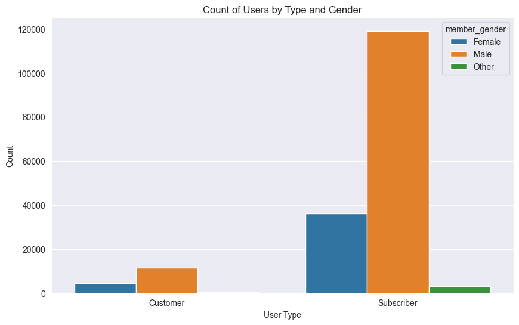

```python
# Group by user type and gender, count trips
user_gender_counts = df.groupby(['user_type', 'member_gender']).size().reset_index(name='count')

# Create barplot showing count by user type and gender
plt.figure(figsize=(10,6))
sb.barplot(x='user_type', y='count', hue='member_gender', data=user_gender_counts)

# Set title and labels
set_plot_labels('Count of Users by Type and Gender', 'User Type', 'Count')


# Display the plot
plt.show()
```

### Did you observe any interesting relationships between the other features (not the main feature(s) of interest)?

Besides user type, I noticed that trip duration could potentially vary with other factors such as gender or time of day, which will be explored further in the multivariate exploration section. There were no surprising interactions yet, but the distribution differences between user types were quite clear.

## Multivariate Exploration

### Question:

How does trip duration vary across user type and gender?

### Observation:

From the facet grid, we can see that for both user types, males generally make up the majority of trips. For each gender group, Customers tend to have longer trip durations compared to Subscribers. The distributions are right-skewed, and the majority of trips are under 1000 seconds across all groups.

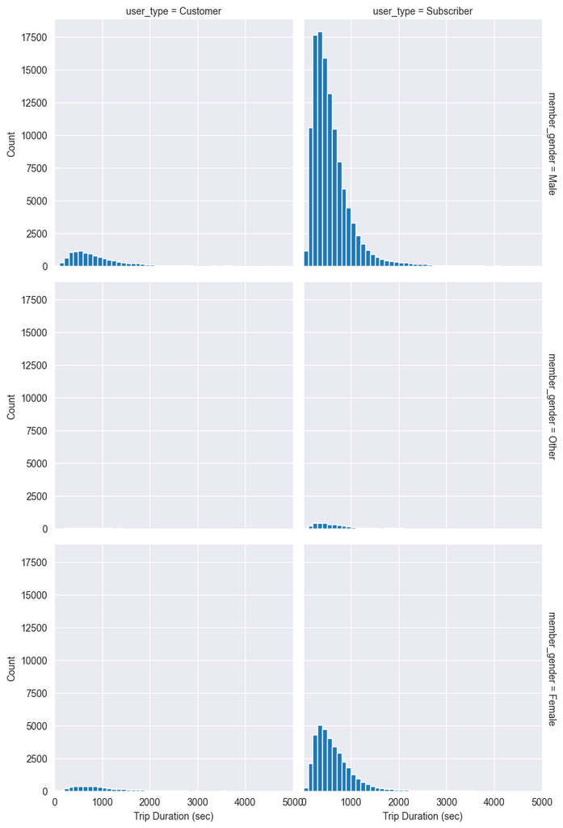

```python
import seaborn as sb

# Create a FacetGrid with user_type as column and member_gender as row
g = sb.FacetGrid(data=df, col='user_type', row='member_gender', height=4, margin_titles=True)

# Map a histogram of trip duration to the grid with bin size of 100 up to 5000
g.map(plt.hist, 'duration_sec', bins=np.arange(0, 5000+100, 100))

# Set axis labels
g.set_axis_labels('Trip Duration (sec)', 'Count')

# Set x-axis limit for clarity
g.set(xlim=(0, 5000))

# Display the plot
plt.show()
```

### Observation:

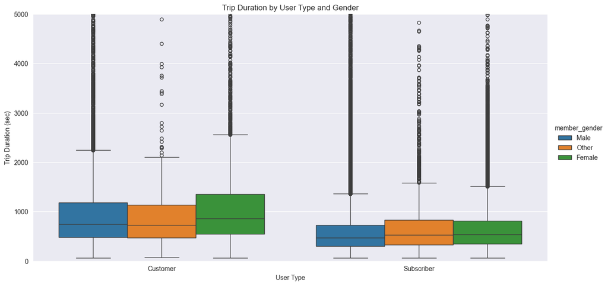

```python
# Create a catplot boxplot of trip duration by user type, colored by gender
g = sb.catplot(data=df, x='user_type', y='duration_sec', hue='member_gender', kind='box', height=6, aspect=2)

# Set axis labels
g.set_axis_labels('User Type', 'Trip Duration (sec)')

# Set y-axis limit for clarity
plt.ylim(0, 5000)

# Set title
plt.title('Trip Duration by User Type and Gender')

# Display the plot
plt.show()
```

### Observation:

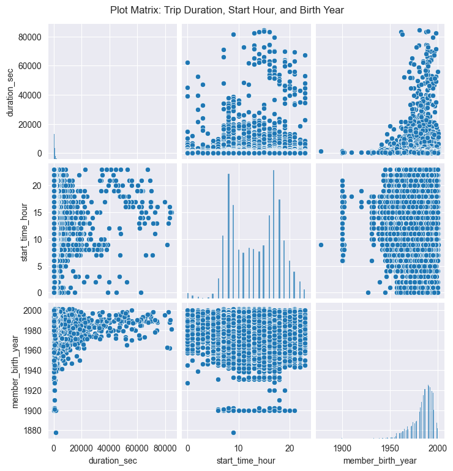

```python
df['start_time'] = pd.to_datetime(df['start_time'])

df['start_time_hour'] = df['start_time'].dt.hour

plot_df = df[['duration_sec', 'start_time_hour', 'member_birth_year']].dropna()

sb.pairplot(data=plot_df, diag_kind='hist')

plt.suptitle('Plot Matrix: Trip Duration, Start Hour, and Birth Year', y=1.02)

plt.show()
```

### Observation:

This scatterplot illustrates how trip duration varies by the hour of the day, differentiated by user type and gender. We observe that:

- Most trips occur during typical commuting hours (around 8 AM and 5 PM).
- **Subscribers** dominate these peak periods, suggesting regular usage patterns likely for work.
- **Customers** are more scattered throughout the day with slightly longer trip durations.
- The difference in trip patterns between genders is subtle but noticeable through marker styles.
- Most trip durations remain below 5000 seconds, reinforcing previous findings from other plots.

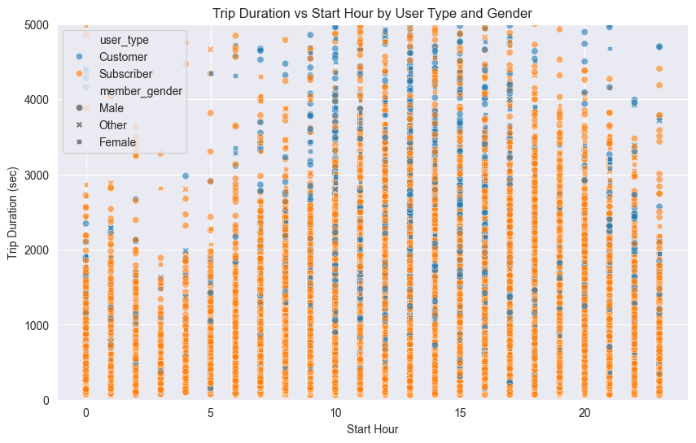

```python
df['start_time'] = pd.to_datetime(df['start_time'])
df['start_time_hour'] = df['start_time'].dt.hour

scatter_df = df[['duration_sec', 'start_time_hour', 'user_type', 'member_gender']].dropna()

plt.figure(figsize=(10,6))
sb.scatterplot(data=scatter_df,
               x='start_time_hour',
               y='duration_sec',
               hue='user_type',
               style='member_gender',
               alpha=0.6)

plt.title('Trip Duration vs Start Hour by User Type and Gender')
plt.xlabel('Start Hour')
plt.ylabel('Trip Duration (sec)')
plt.ylim(0, 5000)
plt.show()
```

### Talk about some of the relationships you observed in this part of the investigation. Were there features that strengthened each other in terms of looking at your feature(s) of interest?

> From the multivariate exploration, I observed that both user type and member gender provided complementary insights when analyzing trip duration. Specifically, the combination of user type and gender helped highlight that Customers, especially female customers, tend to have longer trip durations compared to Subscribers. This strengthened the understanding that user type alone was not sufficient — gender provided additional context to explain variations in trip duration.

## Conclusions

> In this data exploration project, I analyzed the Ford GoBike dataset focusing on trip durations, user types, and member gender. The univariate exploration showed that trip durations are right-skewed, with most trips lasting under 1000 seconds. The bivariate exploration revealed that customers generally take longer trips than subscribers, and that gender has a minor influence, with male users representing the majority of trips.